# Analysis of RNAseq expressions of Eµ-Myc_dCas9a-SAM and B-All samples

Goknur Giner

2022-06-29

# 1 Backgroud

In this report, we explored the expression profiles of the genes that are differentially expressed between Eµ-Myc/dCas9a-SAM and B-All samples. The Eµ-Myc/dCas9a-SAM and B-ALL RNA-seq experiments are sequenced using Illumina NextSeq 2000 and HiSeq 2000 platforms, respectively, as paired-end 100 bp.

```r
> options(digits = 3)
> rm(list = ls())
> # setwd('~/Desktop/Eµ-Myc-dCas9a-SAM_RNASeq_Data')
> setwd("/Volumes/GoogleDrive/My Drive/Professional/Manuscripts/before 2022/2021/Collaborations/SDiepstraten_CRISPRActivationScreen/Eµ-Myc-dCas9a-SAM_RNASeq_Data_RData")
> library(edgeR)
> library(limma)
> library(gplots)
> library(ggplot2)
> library(pheatmap)
> library(DT)
> library(xlsx)
```

# 2 Eµ-Myc/dCas9a-SAM data preparation

## 2.1 Aligning and counting the samples

To align the Eµ-Myc/dCas9a-SAM samples and count the reads, we used Rsubread version 2.2.6 and BioConductor version 3.11.1. Below are the details.

```r
> writeLines(readLines("./scripts/01_align.R"))
```

```
date <- Sys.Date()
sink(paste0(date, "-align.log"), split = TRUE)
library(BiocVersion) # load this to view the version in sessionInfo
library(Rsubread)
R1 <- dir(full.names=TRUE, path="/stornext/Bioinf/data/bioinf-data/Papenfuss_lab/projects/ginerg_papenfuss_lab/Github_projects/SDiepstraten_2021_05_14/fastqfiles/", pattern="*_R1")
R2 <- dir(full.names=TRUE, path="/stornext/Bioinf/data/bioinf-data/Papenfuss_lab/projects/ginerg_papenfuss_lab/Github_projects/SDiepstraten_2021_05_14/fastqfiles/", pattern="*_R2")
bam <- sub("\\.fastq.gz",".bam",basename(R1))
mm10 <- "/stornext/General/data/academic/lab_smyth/smyth/Genome/UCSC/mm10"
Mapping_results <- align(mm10,R1,R2,output_file=bam,useAnnotation=TRUE,annot.inbuilt="mm10",nthreads=16,sortReadsByCoordinates=TRUE)
save(file = "Mapping_results.RData", Mapping_results)
print(sessionInfo())
sink()
```

```r
> writeLines(readLines("./scripts/02_featurecount.R"))
```

```
setwd("/stornext/Bioinf/data/bioinf-data/Papenfuss_lab/projects/ginerg_papenfuss_lab/Github_projects/SDiepstraten_2021_05_14/B_ALL_RNA-Seq_from_Ashley/subjunc_bamfiles")
date <- Sys.Date()
sink(paste0(date, "-featurecount.log"), split = TRUE)
library(BiocVersion) # load this to view the version in sessionInfo
library(Rsubread)
BAM <- dir(pattern=".BAM$")
fc <- featureCounts(BAM, annot.inbuilt = "mm10", isPairedEnd = TRUE)
propmap <- propmapped(BAM)
ann <- getInBuiltAnnotation("mm10")
out.gene <- list(count = fc, propmap = propmap, ann = ann)
save(out.gene, file = paste0(date, "-B_ALL_RNA-Seq_from_Ashley-rsubread-mm10-gene.RData"))
print(sessionInfo())
sink()
```

## 2.2 Checking the number of mapped reads

```r
> load("./RData/Eµ-Myc-dCas9a-SAM_RNASeq.RData")
> propmap <- out.gene$propmap
> propmap$Name <- rownames(propmap)
> ggplot(data = propmap, aes(x = reorder(Name, PropMapped), y = PropMapped)) + geom_bar(stat = "identity",
+     fill = "#FF9999") + theme_minimal() + theme(axis.text.x = element_text(angle = 90,
+     hjust = 0.95, vjust = 0.2)) + ggtitle("Proportion of mapped reads") + xlab("") +
+     ylab("")
> ggplot(data = propmap, aes(x = reorder(Name, NumMapped), y = NumMapped)) + geom_bar(stat = "identity",
+     fill = "#FF9999") + theme_minimal() + theme(axis.text.x = element_text(angle = 90,
+     hjust = 0.95, vjust = 0.2)) + ggtitle("Number of mapped reads") + xlab("") +
+     ylab("")
```

[output not shown]

## 2.3 Annotation

Mouse genome annotation on the gene level is obtained from Rsubread and annotation for each Entrez Gene ID is obtained from the most up to date NCBI Mus_muculus.gene_info file.

```r
> d <- out.gene
> ann <- d$count$annotation
> ann$Chr <- unlist(lapply(strsplit(ann$Chr, ";"), function(x) paste(unique(x), collapse = ",")))
> ann$Strand <- ann$Start <- ann$End <- NULL
> ann$Length <- ann$Length
> ncbi.file <- "indices/Mus_musculus.gene_info"
> ncbi.L1 <- readLines(ncbi.file, n = 1)
> ncbi.colname <- unlist(strsplit(substring(ncbi.L1, 9, 240), "\t"))
> ncbi <- read.delim(ncbi.file, skip = 1, head = F, stringsAsFactors = F, quote = "")
> ncbi <- ncbi[, -1]
> colnames(ncbi) <- ncbi.colname
> m <- match(ann$GeneID, ncbi$GeneID)
> ann$Symbol <- ncbi$Symbol[m]
> ann$Type <- ncbi$type_of_gene[m]
> ann$Description <- ncbi$description[m]
> head(ann)
> counts <- d$count$counts
> d <- DGEList(counts, genes = ann[, c("Symbol", "Chr", "Length", "Description", "Type")])
> rownames(d$counts) <- d$genes$Symbol
> dim(d)
```

## 2.4 Creating the DGEList object

First we create a new DGEList object, which includes information about read counts for each gene, sample information and gene annotations. The new DGEList object has 27179 genes and 18 samples.

```r
> d$samples$SampleNo <- strsplit2(rownames(d$samples), "_")[, 1]
> d <- d[, order(as.numeric(d$samples$SampleNo))]
> Targets <- read.csv("Targets.csv")
> d$samples$Type <- Targets$Type[1:18]
> d$samples$Subtype <- Targets$Subtype[1:18]
> d$samples$BioRep <- Targets$Biorep[1:18]
> dim(d)
> save(d, file = "./RData/DHL_DGEList.RData")
```

# 3 B-ALL data preparation

## 3.1 Annotaion of B-ALL

```r
> load("./RData/2022-05-03-B_ALL_RNA-Seq_from_Ashley-rsubread-mm10-gene.RData")
> d <- out.gene
> ann <- d$count$annotation
> ann$Chr <- unlist(lapply(strsplit(ann$Chr, ";"), function(x) paste(unique(x), collapse = ",")))
> ann$Strand <- ann$Start <- ann$End <- NULL
> ann$Length <- ann$Length
> ncbi.file <- "indices/Mus_musculus.gene_info"
> ncbi.L1 <- readLines(ncbi.file, n = 1)
> ncbi.colname <- unlist(strsplit(substring(ncbi.L1, 9, 240), "\t"))
> ncbi <- read.delim(ncbi.file, skip = 1, head = F, stringsAsFactors = F, quote = "")
> ncbi <- ncbi[, -1]
> colnames(ncbi) <- ncbi.colname
> m <- match(ann$GeneID, ncbi$GeneID)
> ann$Symbol <- ncbi$Symbol[m]
> ann$Type <- ncbi$type_of_gene[m]
> ann$Description <- ncbi$description[m]
> head(ann)
> counts <- d$count$counts
> d <- DGEList(counts, genes = ann[, c("Symbol", "Chr", "Length", "Description", "Type")])
> rownames(d$counts) <- d$genes$Symbol
> dim(d)
> save(d, file = "./RData/B-ALL_DGEList.RData")
```

# 4 Combine Pre-B-ALL and Eμ-Myc/dCas9a-SAMKI/+/sgBcl-2 lymphoma counts in the same RData file

```r
> load("./RData/B-ALL_DGEList.RData")
> m <- !is.na(d$genes$Symbol)
> d.bll <- d[m, ]
> dim(d.bll)
```

```
[1] 25869     2
```

```r
> d.bll
```

```
An object of class "DGEList"
$counts
        P190CreERLSLErg__138_C8HKNANXX_TAGCTT_L005_R1.fastq.gz.subjunc.BAM
Xkr4                                                                     0
Gm19938                                                                  0
Gm10568                                                                  0
Rp1                                                                      0
Sox17                                                                    0
        P190RagCreErg__99_C8HKNANXX_GGCTAC_L005_R1.fastq.gz.subjunc.BAM
Xkr4                                                                  0
Gm19938                                                               0
Gm10568                                                               0
Rp1                                                                   0
Sox17                                                                 0
25864 more rows ...

$samples
                                                                   group
P190CreERLSLErg__138_C8HKNANXX_TAGCTT_L005_R1.fastq.gz.subjunc.BAM     1
P190RagCreErg__99_C8HKNANXX_GGCTAC_L005_R1.fastq.gz.subjunc.BAM        1
                                                                   lib.size
P190CreERLSLErg__138_C8HKNANXX_TAGCTT_L005_R1.fastq.gz.subjunc.BAM 15074122
P190RagCreErg__99_C8HKNANXX_GGCTAC_L005_R1.fastq.gz.subjunc.BAM    12576273
                                                                   norm.factors
P190CreERLSLErg__138_C8HKNANXX_TAGCTT_L005_R1.fastq.gz.subjunc.BAM            1
P190RagCreErg__99_C8HKNANXX_GGCTAC_L005_R1.fastq.gz.subjunc.BAM               1

$genes
           Symbol  Chr Length                           Description
497097       Xkr4 chr1   3634     X-linked Kx blood group related 4
100503874 Gm19938 chr1   3259                 predicted gene, 19938
100038431 Gm10568 chr1   1634                  predicted gene 10568
19888         Rp1 chr1   9747        retinitis pigmentosa 1 (human)
20671       Sox17 chr1   3130 SRY (sex determining region Y)-box 17
                    Type
497097    protein-coding
100503874          ncRNA
100038431        unknown
19888     protein-coding
20671     protein-coding
25864 more rows ...
```

```r
> load("./RData/DHL_DGEList.RData")
> m <- !is.na(d$genes$Symbol)
> d.dhl <- d[m, ]
> d.dhl
```

```
An object of class "DGEList"
$counts
        1_MEFs_1_S1_L001_R1_001.bam 2_MEFs_2_S2_L001_R1_001.bam
Xkr4                             22                          35
Gm19938                           0                           0
Gm10568                           0                           0
Rp1                               1                           1
Sox17                             9                          15
        3_MEFs_1_NTC1_S3_L001_R1_001.bam 5_MEFs_2_NTC1_S4_L001_R1_001.bam
Xkr4                                  27                               27
Gm19938                                1                                2
Gm10568                                0                                0
Rp1                                    5                                1
Sox17                                  0                                1
        7_MEFs_1_BCL2_1_S5_L001_R1_001.bam 8_MEFs_1_BCL2_2_S6_L001_R1_001.bam
Xkr4                                    12                                 14
Gm19938                                  0                                  0
Gm10568                                  0                                  0
Rp1                                      0                                  5
Sox17                                    0                                  0
        9_MEFs_2_BCL2_1_S7_L001_R1_001.bam 10_MEFs_2_BCL2_2_S8_L001_R1_001.bam
Xkr4                                    22                                  24
Gm19938                                  0                                   0
Gm10568                                  0                                   0
Rp1                                      0                                   0
Sox17                                    0                                   0
        11_WT_MEFs_1_1_S9_L001_R1_001.bam 13_WT_MEFs_2_S10_L001_R1_001.bam
Xkr4                                   16                               35
Gm19938                                 0                                2
Gm10568                                 0                                0
Rp1                                     3                                0
Sox17                                   0                               15
        14_179_IgMp_S11_L001_R1_001.bam 15_180_IgMp_S12_L001_R1_001.bam
Xkr4                                  0                               0
Gm19938                               0                               0
Gm10568                               0                               0
Rp1                                   0                               0
Sox17                                 0                               0
        16_202_IgMp_S13_L001_R1_001.bam 17_213_IgMp_S14_L001_R1_001.bam
Xkr4                                  0                               0
```

[output cut: 38 more lines]

```

$genes
           Symbol  Chr Length                           Description
497097       Xkr4 chr1   3634     X-linked Kx blood group related 4
100503874 Gm19938 chr1   3259                 predicted gene, 19938
100038431 Gm10568 chr1   1634                  predicted gene 10568
19888         Rp1 chr1   9747        retinitis pigmentosa 1 (human)
20671       Sox17 chr1   3130 SRY (sex determining region Y)-box 17
                    Type
497097    protein-coding
100503874          ncRNA
100038431        unknown
19888     protein-coding
20671     protein-coding
25864 more rows ...
```

```r
> sum(!rownames(d.dhl$genes) == rownames(d.bll$genes))
```

```
[1] 0
```

```r
> counts <- cbind(d.dhl$counts, d.bll$counts)
> head(counts)
```

```
        1_MEFs_1_S1_L001_R1_001.bam 2_MEFs_2_S2_L001_R1_001.bam
Xkr4                             22                          35
Gm19938                           0                           0
Gm10568                           0                           0
Rp1                               1                           1
Sox17                             9                          15
Mrpl15                          774                         850
        3_MEFs_1_NTC1_S3_L001_R1_001.bam 5_MEFs_2_NTC1_S4_L001_R1_001.bam
Xkr4                                  27                               27
Gm19938                                1                                2
Gm10568                                0                                0
Rp1                                    5                                1
Sox17                                  0                                1
Mrpl15                               746                              860
        7_MEFs_1_BCL2_1_S5_L001_R1_001.bam 8_MEFs_1_BCL2_2_S6_L001_R1_001.bam
Xkr4                                    12                                 14
Gm19938                                  0                                  0
Gm10568                                  0                                  0
Rp1                                      0                                  5
Sox17                                    0                                  0
Mrpl15                                 753                                859
        9_MEFs_2_BCL2_1_S7_L001_R1_001.bam 10_MEFs_2_BCL2_2_S8_L001_R1_001.bam
Xkr4                                    22                                  24
Gm19938                                  0                                   0
Gm10568                                  0                                   0
Rp1                                      0                                   0
Sox17                                    0                                   0
Mrpl15                                 737                                 666
        11_WT_MEFs_1_1_S9_L001_R1_001.bam 13_WT_MEFs_2_S10_L001_R1_001.bam
Xkr4                                   16                               35
Gm19938                                 0                                2
Gm10568                                 0                                0
Rp1                                     3                                0
Sox17                                   0                               15
Mrpl15                                691                             1345
        14_179_IgMp_S11_L001_R1_001.bam 15_180_IgMp_S12_L001_R1_001.bam
Xkr4                                  0                               0
Gm19938                               0                               0
Gm10568                               0                               0
Rp1                                   0                               0
```

[output cut: 29 more lines]

```
Mrpl15                                    1561
        P190CreERLSLErg__138_C8HKNANXX_TAGCTT_L005_R1.fastq.gz.subjunc.BAM
Xkr4                                                                     0
Gm19938                                                                  0
Gm10568                                                                  0
Rp1                                                                      0
Sox17                                                                    0
Mrpl15                                                                1240
        P190RagCreErg__99_C8HKNANXX_GGCTAC_L005_R1.fastq.gz.subjunc.BAM
Xkr4                                                                  0
Gm19938                                                               0
Gm10568                                                               0
Rp1                                                                   0
Sox17                                                                 0
Mrpl15                                                              816
```

```r
> dim(counts)
```

```
[1] 25869    20
```

```r
> d <- DGEList(counts, genes = d.dhl$genes)
> rownames(d$genes) <- rownames(d.dhl$genes)
> Targets <- read.csv("Targets.csv")
> d$samples$Type <- Targets$Type
> d$samples$Subtype <- Targets$Subtype
> d$samples$BioRep <- Targets$Biorep
> d$samples$Origin <- Targets$Origin
> dim(d)
```

```
[1] 25869    20
```

```r
> save(d, file = "./RData/Combined_DGEList.RData")
> dim(d)
```

```
[1] 25869    20
```

# 5 Figure 6a

```r
> load("./RData/Combined_DGEList.RData")
> # Select Pre-B-ALL and Eμ-Myc/dCas9a-SAMKI/+/sgBcl-2 lymphoma samples
> d <- d[, rownames(d$samples) %in% c("14_179_IgMp_S11_L001_R1_001.bam", "15_180_IgMp_S12_L001_R1_001.bam",
+     "16_202_IgMp_S13_L001_R1_001.bam", "17_213_IgMp_S14_L001_R1_001.bam", "18_214_IgMn_S15_L001_R1_001.bam",
+     "19_216_IgMn_S16_L001_R1_001.bam", "P190CreERLSLErg__138_C8HKNANXX_TAGCTT_L005_R1.fastq.gz.subjunc.BAM",
+     "P190RagCreErg__99_C8HKNANXX_GGCTAC_L005_R1.fastq.gz.subjunc.BAM")]
> dim(d)
```

```
[1] 25869     8
```

```r
> d$samples$Subgroup <- "B-ALL"
> d$samples$Subgroup[d$samples$Subtype == "IgM"] = "Eµ-Myc_dCas9a-SAM"
>
> ## Filter and normalise
> i <- d$genes$Type %in% c("ncRNA", "protein-coding", "scRNA", "snoRNA", "snRNA")
> d <- d[i, , keep.lib.size = FALSE]
> i <- filterByExpr(d, group = d$samples$Subgroup)
> d <- d[i, , keep.lib.size = FALSE]
> dim(d)
```

```
[1] 13521     8
```

```r
> d <- calcNormFactors(d, method = "TMM")
> d$samples
```

```
                                                                   group
14_179_IgMp_S11_L001_R1_001.bam                                        1
15_180_IgMp_S12_L001_R1_001.bam                                        1
16_202_IgMp_S13_L001_R1_001.bam                                        1
17_213_IgMp_S14_L001_R1_001.bam                                        1
18_214_IgMn_S15_L001_R1_001.bam                                        1
19_216_IgMn_S16_L001_R1_001.bam                                        1
P190CreERLSLErg__138_C8HKNANXX_TAGCTT_L005_R1.fastq.gz.subjunc.BAM     1
P190RagCreErg__99_C8HKNANXX_GGCTAC_L005_R1.fastq.gz.subjunc.BAM        1
                                                                   lib.size
14_179_IgMp_S11_L001_R1_001.bam                                    23398099
15_180_IgMp_S12_L001_R1_001.bam                                    25487901
16_202_IgMp_S13_L001_R1_001.bam                                    25123562
17_213_IgMp_S14_L001_R1_001.bam                                    19138074
18_214_IgMn_S15_L001_R1_001.bam                                    24283534
19_216_IgMn_S16_L001_R1_001.bam                                    22114524
P190CreERLSLErg__138_C8HKNANXX_TAGCTT_L005_R1.fastq.gz.subjunc.BAM 14581111
P190RagCreErg__99_C8HKNANXX_GGCTAC_L005_R1.fastq.gz.subjunc.BAM    12112354
                                                                   norm.factors
14_179_IgMp_S11_L001_R1_001.bam                                           0.950
15_180_IgMp_S12_L001_R1_001.bam                                           1.004
16_202_IgMp_S13_L001_R1_001.bam                                           0.931
17_213_IgMp_S14_L001_R1_001.bam                                           0.949
18_214_IgMn_S15_L001_R1_001.bam                                           0.899
19_216_IgMn_S16_L001_R1_001.bam                                           0.923
P190CreERLSLErg__138_C8HKNANXX_TAGCTT_L005_R1.fastq.gz.subjunc.BAM        1.158
P190RagCreErg__99_C8HKNANXX_GGCTAC_L005_R1.fastq.gz.subjunc.BAM           1.235
                                                                      Type
14_179_IgMp_S11_L001_R1_001.bam                                       IgMp
15_180_IgMp_S12_L001_R1_001.bam                                       IgMp
16_202_IgMp_S13_L001_R1_001.bam                                       IgMp
17_213_IgMp_S14_L001_R1_001.bam                                       IgMp
18_214_IgMn_S15_L001_R1_001.bam                                       IgMn
19_216_IgMn_S16_L001_R1_001.bam                                       IgMn
P190CreERLSLErg__138_C8HKNANXX_TAGCTT_L005_R1.fastq.gz.subjunc.BAM IgAshly
P190RagCreErg__99_C8HKNANXX_GGCTAC_L005_R1.fastq.gz.subjunc.BAM    IgAshly
                                                                   Subtype
14_179_IgMp_S11_L001_R1_001.bam                                        IgM
15_180_IgMp_S12_L001_R1_001.bam                                        IgM
16_202_IgMp_S13_L001_R1_001.bam                                        IgM
```

[output cut: 8 more lines]

```
16_202_IgMp_S13_L001_R1_001.bam                                       202
17_213_IgMp_S14_L001_R1_001.bam                                       213
18_214_IgMn_S15_L001_R1_001.bam                                       214
19_216_IgMn_S16_L001_R1_001.bam                                       216
P190CreERLSLErg__138_C8HKNANXX_TAGCTT_L005_R1.fastq.gz.subjunc.BAM      1
P190RagCreErg__99_C8HKNANXX_GGCTAC_L005_R1.fastq.gz.subjunc.BAM         2
                                                                            Subgroup
14_179_IgMp_S11_L001_R1_001.bam                                    Eµ-Myc_dCas9a-SAM
15_180_IgMp_S12_L001_R1_001.bam                                    Eµ-Myc_dCas9a-SAM
16_202_IgMp_S13_L001_R1_001.bam                                    Eµ-Myc_dCas9a-SAM
17_213_IgMp_S14_L001_R1_001.bam                                    Eµ-Myc_dCas9a-SAM
18_214_IgMn_S15_L001_R1_001.bam                                    Eµ-Myc_dCas9a-SAM
19_216_IgMn_S16_L001_R1_001.bam                                    Eµ-Myc_dCas9a-SAM
P190CreERLSLErg__138_C8HKNANXX_TAGCTT_L005_R1.fastq.gz.subjunc.BAM             B-ALL
P190RagCreErg__99_C8HKNANXX_GGCTAC_L005_R1.fastq.gz.subjunc.BAM                B-ALL
```

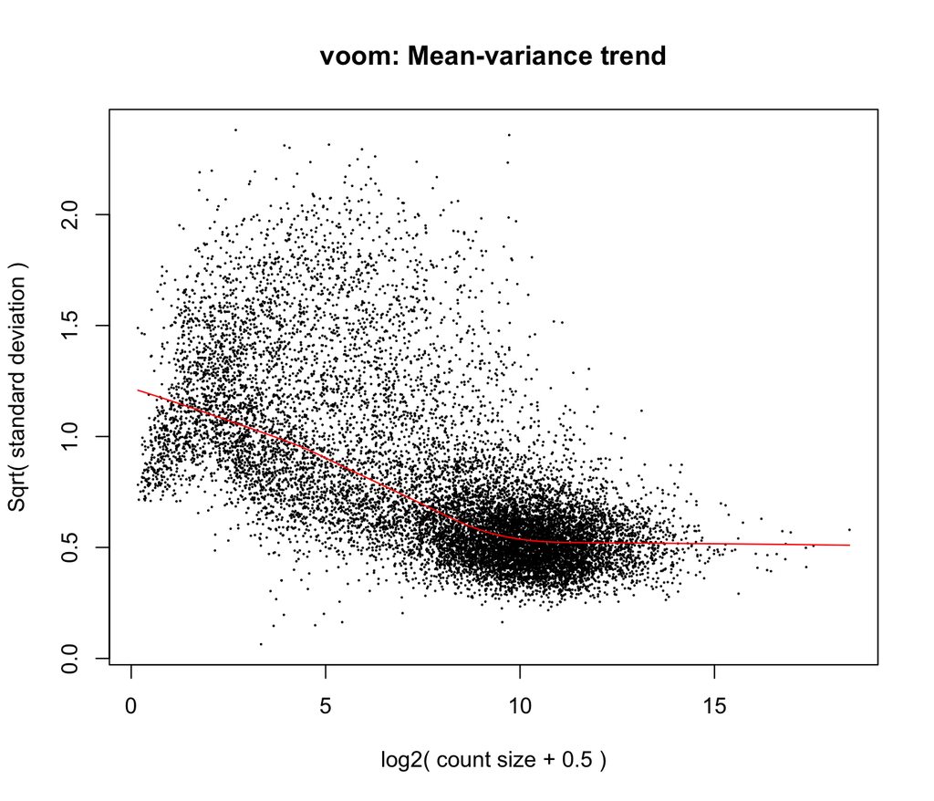

```r
> ## DE analysis
> group <- factor(d$samples$Subgroup)  # B-ALL is the base group
> design <- model.matrix(~group)
> v <- voomLmFit(d, design, plot = TRUE)
```

```r
> fit <- eBayes(v, robust = TRUE)
> summary(dt <- decideTests(fit))
```

```
       (Intercept) groupEµ-Myc_dCas9a-SAM
Down           272                   3291
NotSig        2376                   7771
Up           10873                   2459
```

```r
> toptable <- topTable(fit, n = Inf, coef = "groupEµ-Myc_dCas9a-SAM")
> head(toptable, 20)
```

```
             Symbol   Chr Length
Gm10029     Gm10029 chr13    333
Igf2           Igf2  chr7   4236
Anxa2         Anxa2  chr9   1374
S100a4       S100a4  chr3    499
H19             H19  chr7   2615
Rpl13-ps6 Rpl13-ps6  chr3    636
Eng             Eng  chr2   3572
Rps16         Rps16  chr7    615
Cbx3           Cbx3  chr6   1803
Rpl5           Rpl5  chr5   2019
Osr1           Osr1 chr12   2011
Serpinh1   Serpinh1  chr7   2444
Pls3           Pls3  chrX   3421
Arhgef40   Arhgef40 chr14   5643
Col1a1       Col1a1 chr11   4709
Cycs           Cycs  chr6   3059
Cdsn           Cdsn chr17   2678
Prnp           Prnp  chr2   2186
S100a16     S100a16  chr3   1061
Plin4         Plin4 chr17   5755
                                                          Description
Gm10029                                          predicted gene 10029
Igf2                                     insulin-like growth factor 2
Anxa2                                                      annexin A2
S100a4                                S100 calcium binding protein A4
H19                    H19, imprinted maternally expressed transcript
Rpl13-ps6                         ribosomal protein L13, pseudogene 6
Eng                                                          endoglin
Rps16                                           ribosomal protein S16
Cbx3                                                      chromobox 3
Rpl5                                             ribosomal protein L5
Osr1                       odd-skipped related transcription factor 1
Serpinh1  serine (or cysteine) peptidase inhibitor, clade H, member 1
Pls3                                            plastin 3 (T-isoform)
Arhgef40              Rho guanine nucleotide exchange factor (GEF) 40
Col1a1                                      collagen, type I, alpha 1
Cycs                                            cytochrome c, somatic
Cdsn                                                   corneodesmosin
Prnp                                                    prion protein
```

[output cut: 8 more lines]

```
Rpl13-ps6 protein-coding   8.17   8.654  22.1 7.48e-09  1.01e-05 10.29
Eng       protein-coding  -8.54   0.711 -23.1 5.12e-09  9.45e-06 10.27
Rps16     protein-coding   3.70   7.499  19.6 2.02e-08  1.10e-05 10.16
Cbx3      protein-coding   3.97   6.835  20.0 1.73e-08  1.10e-05 10.14
Rpl5      protein-coding   3.18   7.407  18.4 3.50e-08  1.16e-05  9.65
Osr1      protein-coding -10.30  -2.607 -26.1 1.78e-09  8.03e-06  9.64
Serpinh1  protein-coding  -9.10   0.798 -20.2 1.56e-08  1.10e-05  9.54
Pls3      protein-coding  -8.14  -0.318 -20.5 1.41e-08  1.10e-05  9.32
Arhgef40  protein-coding  -6.82  -0.268 -20.1 1.64e-08  1.10e-05  9.25
Col1a1    protein-coding  -8.66   2.562 -18.1 4.02e-08  1.16e-05  9.22
Cycs      protein-coding   4.72   5.979  18.5 3.30e-08  1.16e-05  9.17
Cdsn      protein-coding -10.14  -2.119 -22.6 6.19e-09  9.45e-06  9.13
Prnp      protein-coding  -9.18  -0.354 -19.8 1.90e-08  1.10e-05  9.08
S100a16   protein-coding  -9.41  -2.833 -22.5 6.29e-09  9.45e-06  8.95
Plin4     protein-coding  -9.70  -1.718 -20.9 1.16e-08  1.10e-05  8.88
```

```r
> write.csv(toptable, paste0("tables/", Sys.Date(), "-DE_gene_list_groupEµ-Myc_dCas9a-SAM_vs_B-ALL_GGiner.csv"))
>
> ## Heatmap of top 200 DE genes
> gene.list <- toptable[toptable$adj.P.Val < 0.05, ]$Symbol
> bp <- d$counts
> rownames(bp) <- d$genes$Symbol
> colnames(bp) <- d$samples$BioRep
> dim(bp)
```

```
[1] 13521     8
```

```r
> head(bp)
```

```
         179  180  202  213  214  216    1   2
Mrpl15  2053 2460 2797 1992 4213 2725 1240 816
Lypla1  1728 1487 2480 1499 2424 1786 1149 752
Gm19860    6    7   15    6   22   11    2   3
Tcea1   4469 4789 4499 3545 6206 3716 1227 750
Atp6v1h 1345 1318 1505  964 1297 1063 1147 919
Rb1cc1  1330 1031 1072  891 1568  914  883 772
```

```r
> dim(bp <- bp[rowSums(bp) != 0, ])
```

```
[1] 13521     8
```

```r
> dim(bp <- bp[rownames(bp) %in% gene.list[1:200], ])
```

```
[1] 200   8
```

```r
> m <- match(rownames(bp), gene.list[1:200])
> # CPM normalisation + Row scaling for 3 main IG type
>
> # excel table of genes with BCL2 and MYC translocations
> genes_mono <- read.csv("./genes_BCL2_MYC.csv", header = FALSE)
> write.csv(toptable[toptable$Symbol %in% genes_mono$V1, ], "./tables/DE_results_for_genes_with_BCL2_or_MYC_translocations.csv")
>
> # pathway analysis
> Mm.c2 <- readRDS("./MSigDB/Mm.c2.all.v7.1.entrez.rds")
> t.stats <- fit$t[, "groupEµ-Myc_dCas9a-SAM"]
> names(t.stats) <- rownames(fit$genes)
> camera.table <- cameraPR(t.stats, Mm.c2)
> camera.table <- camera.table[camera.table$FDR <= 0.05, ]
> write.xlsx(camera.table, paste0("./tables/", Sys.Date(), "-MSigDB_Eµ-Myc_dCas9a-SAMvsB-ALL-GGiner.xlsx"))
>
> pdf("./figures/Figure_6a.pdf", width = 10, height = 8)
> H_res <- camera.table[grep("MYC|DLBCL", rownames(camera.table)), ]
> FDR = 0.05
> h_plot <- H_res[H_res$FDR < FDR & H_res$Direction == "Up", ]
> tmp <- H_res[H_res$FDR < FDR & H_res$Direction == "Down", ]
> tmp <- tmp[nrow(tmp):1, ]
> h_plot <- rbind(h_plot, tmp)
> h_plot$FDR <- -log10(h_plot$FDR)
> h_plot <- h_plot[nrow(h_plot):1, ]
> h_cols <- as.factor(h_plot$Direction)
> levels(h_cols) <- c(4, 2)
> par(mar = c(5, 20, 4, 2))
> barplot(h_plot$FDR, las = 2, horiz = TRUE, names.arg = rownames(h_plot), cex.names = 0.6,
+     axes = TRUE, border = 1, main = "Enriched gene sets in Eµ-Myc_dCas9a-SAM compared to B-ALL",
+     xlab = "-log10(FDR)", col = as.character(h_cols))
> abline(v = -log10(0.05), lty = 2, col = 1)
> legend("right", c("Up", "Down"), pch = 15, col = c(2, 4))
> dev.off()
```

# 6 Supp Figure 3d

## 6.1 Filtering and normalising

In this section, we remove the genes with no annotation and with low counts across all libraries. After filtering, 14768 genes kept in the analysis.

```r
> load("./RData/Combined_DGEList.RData")
> d <- d[, d$samples$Type == "MEFs"]
> dim(d)
```

```
[1] 25869    10
```

```r
> i <- d$genes$Type %in% c("ncRNA", "protein-coding", "scRNA", "snoRNA", "snRNA")
> d <- d[i, , keep.lib.size = FALSE]
> i <- filterByExpr(d, group = d$samples$Subtype)
> d <- d[i, , keep.lib.size = FALSE]
> dim(d)
```

```
[1] 14768    10
```

After we filtered the low counts, we performed TMM normalisation to eliminate composition biases between libraries.

```r
> d <- calcNormFactors(d, method = "TMM")
> d$samples
```

```
                                    group lib.size norm.factors Type Subtype
1_MEFs_1_S1_L001_R1_001.bam             1 22538080        1.005 MEFs    MEFs
2_MEFs_2_S2_L001_R1_001.bam             1 22411145        1.007 MEFs    MEFs
3_MEFs_1_NTC1_S3_L001_R1_001.bam        1 19539855        1.046 MEFs     NTC
5_MEFs_2_NTC1_S4_L001_R1_001.bam        1 22789058        1.020 MEFs     NTC
7_MEFs_1_BCL2_1_S5_L001_R1_001.bam      1 21980970        0.973 MEFs  BCL2_1
8_MEFs_1_BCL2_2_S6_L001_R1_001.bam      1 25346725        0.968 MEFs  BCL2_1
9_MEFs_2_BCL2_1_S7_L001_R1_001.bam      1 23633795        0.977 MEFs  BCL2_2
10_MEFs_2_BCL2_2_S8_L001_R1_001.bam     1 22197495        0.940 MEFs  BCL2_2
11_WT_MEFs_1_1_S9_L001_R1_001.bam       1 17984327        0.979 MEFs      WT
13_WT_MEFs_2_S10_L001_R1_001.bam        1 25306316        1.092 MEFs      WT
                                    BioRep
1_MEFs_1_S1_L001_R1_001.bam              1
2_MEFs_2_S2_L001_R1_001.bam              2
3_MEFs_1_NTC1_S3_L001_R1_001.bam         1
5_MEFs_2_NTC1_S4_L001_R1_001.bam         2
7_MEFs_1_BCL2_1_S5_L001_R1_001.bam       1
8_MEFs_1_BCL2_2_S6_L001_R1_001.bam       2
9_MEFs_2_BCL2_1_S7_L001_R1_001.bam       1
10_MEFs_2_BCL2_2_S8_L001_R1_001.bam      2
11_WT_MEFs_1_1_S9_L001_R1_001.bam        1
13_WT_MEFs_2_S10_L001_R1_001.bam         2
```

## 6.2 Deciding the design of the experiment and Estimating dispersion and BCV plot

Next we define the design matrix based on the experimental design. Then we estimate the dispersion between biological replicates.

```r
> Experiment <- factor(d$samples$Subtype, levels = c("WT", "BCL2_1", "BCL2_2", "NTC",
+     "MEFs"))
> design <- model.matrix(~Experiment)
> d <- estimateDisp(d, design = design)
> d$common.dispersion
```

```
[1] 0.0688
```

The square root of the common dispersion gives the coefficient of variation of biological variation. Here the common dispersion is found to be 0.0688, so the coefficient of biological variation is around 0.262. The dispersion estimates can be viewed in a BCV plot:

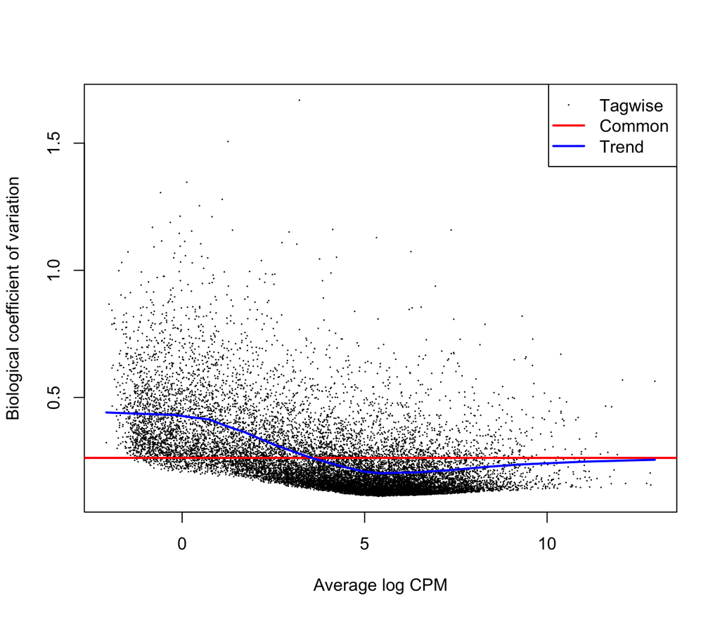

```r
> plotBCV(d)
```

The biological coefficient of variation (BCV) plots show the BCV for each gene.

## 6.3 Differential expression analysis

Here we performed limma:voomLmFit pipeline in limma R package to conduct a differential expression analysis.

## 6.4 Groups compared to NTC

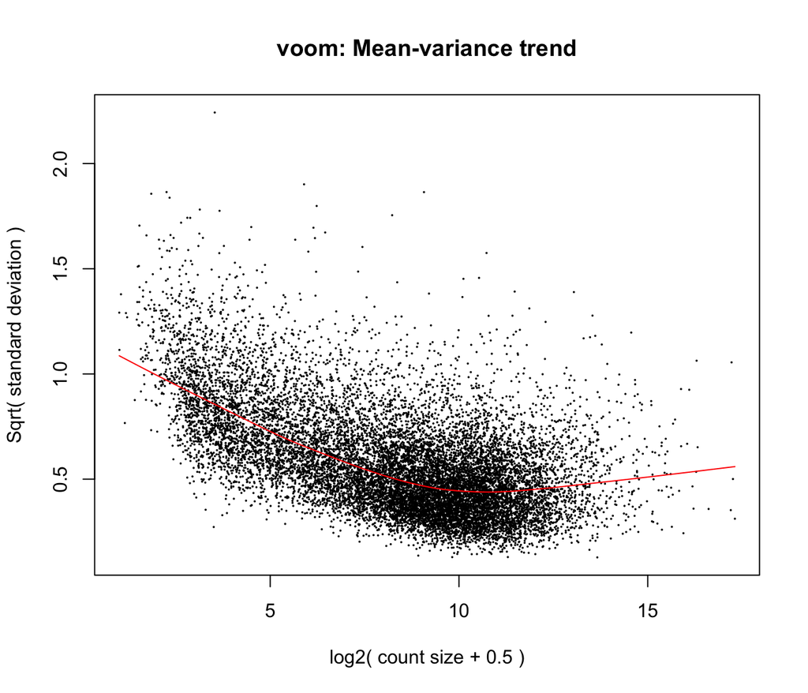

```r
> Experiment <- factor(d$samples$Subtype, levels = c("NTC", "BCL2_1", "BCL2_2", "WT",
+     "MEFs"))
> design <- model.matrix(~Experiment)
> v <- voomLmFit(d, design, plot = TRUE)
```

```r
> fit <- eBayes(v, robust = TRUE)
> summary(dt <- decideTests(fit))
```

```
       (Intercept) ExperimentBCL2_1 ExperimentBCL2_2 ExperimentWT
Down           512                1                8            6
NotSig        2044            14764            14728        14762
Up           12212                3               32            0
       ExperimentMEFs
Down              198
NotSig          14370
Up                200
```

```r
> pdf("./figures/Sup_Figure_3d.pdf")
> plotMD(fit, column = 4, status = dt[, 4], main = "WT MEFs vs NTC")
> abline(h = c(-1, 1), col = "blue")
> dev.off()
```

# 7 Figure 6d

```r
> load("./RData/Combined_DGEList.RData")
> # Heatmap and pathway analysis with Ig negative samples
> d <- d[, rownames(d$samples) %in% c("14_179_IgMp_S11_L001_R1_001.bam", "15_180_IgMp_S12_L001_R1_001.bam",
+     "16_202_IgMp_S13_L001_R1_001.bam", "17_213_IgMp_S14_L001_R1_001.bam", "18_214_IgMn_S15_L001_R1_001.bam",
+     "19_216_IgMn_S16_L001_R1_001.bam", "P190CreERLSLErg__138_C8HKNANXX_TAGCTT_L005_R1.fastq.gz.subjunc.BAM",
+     "P190RagCreErg__99_C8HKNANXX_GGCTAC_L005_R1.fastq.gz.subjunc.BAM")]
> dim(d)
```

```
[1] 25869     8
```

```r
> d$samples$Subgroup[d$samples$Subtype == "B-ALL"] = "B-ALL"
> d$samples$Subgroup[d$samples$Type == "IgMp"] = "DHL.IgM.positive"
> d$samples$Subgroup[d$samples$Type == "IgMn"] = "DHL.IgM.negative"
>
> ## Filter and normalise
> i <- d$genes$Type %in% c("ncRNA", "protein-coding", "scRNA", "snoRNA", "snRNA")
> d <- d[i, , keep.lib.size = FALSE]
> i <- filterByExpr(d, group = d$samples$Subgroup)
> d <- d[i, , keep.lib.size = FALSE]
> dim(d)
```

```
[1] 13521     8
```

```r
> d <- calcNormFactors(d, method = "TMM")
> d$samples
```

```
                                                                   group
14_179_IgMp_S11_L001_R1_001.bam                                        1
15_180_IgMp_S12_L001_R1_001.bam                                        1
16_202_IgMp_S13_L001_R1_001.bam                                        1
17_213_IgMp_S14_L001_R1_001.bam                                        1
18_214_IgMn_S15_L001_R1_001.bam                                        1
19_216_IgMn_S16_L001_R1_001.bam                                        1
P190CreERLSLErg__138_C8HKNANXX_TAGCTT_L005_R1.fastq.gz.subjunc.BAM     1
P190RagCreErg__99_C8HKNANXX_GGCTAC_L005_R1.fastq.gz.subjunc.BAM        1
                                                                   lib.size
14_179_IgMp_S11_L001_R1_001.bam                                    23398099
15_180_IgMp_S12_L001_R1_001.bam                                    25487901
16_202_IgMp_S13_L001_R1_001.bam                                    25123562
17_213_IgMp_S14_L001_R1_001.bam                                    19138074
18_214_IgMn_S15_L001_R1_001.bam                                    24283534
19_216_IgMn_S16_L001_R1_001.bam                                    22114524
P190CreERLSLErg__138_C8HKNANXX_TAGCTT_L005_R1.fastq.gz.subjunc.BAM 14581111
P190RagCreErg__99_C8HKNANXX_GGCTAC_L005_R1.fastq.gz.subjunc.BAM    12112354
                                                                   norm.factors
14_179_IgMp_S11_L001_R1_001.bam                                           0.950
15_180_IgMp_S12_L001_R1_001.bam                                           1.004
16_202_IgMp_S13_L001_R1_001.bam                                           0.931
17_213_IgMp_S14_L001_R1_001.bam                                           0.949
18_214_IgMn_S15_L001_R1_001.bam                                           0.899
19_216_IgMn_S16_L001_R1_001.bam                                           0.923
P190CreERLSLErg__138_C8HKNANXX_TAGCTT_L005_R1.fastq.gz.subjunc.BAM        1.158
P190RagCreErg__99_C8HKNANXX_GGCTAC_L005_R1.fastq.gz.subjunc.BAM           1.235
                                                                      Type
14_179_IgMp_S11_L001_R1_001.bam                                       IgMp
15_180_IgMp_S12_L001_R1_001.bam                                       IgMp
16_202_IgMp_S13_L001_R1_001.bam                                       IgMp
17_213_IgMp_S14_L001_R1_001.bam                                       IgMp
18_214_IgMn_S15_L001_R1_001.bam                                       IgMn
19_216_IgMn_S16_L001_R1_001.bam                                       IgMn
P190CreERLSLErg__138_C8HKNANXX_TAGCTT_L005_R1.fastq.gz.subjunc.BAM IgAshly
P190RagCreErg__99_C8HKNANXX_GGCTAC_L005_R1.fastq.gz.subjunc.BAM    IgAshly
                                                                   Subtype
14_179_IgMp_S11_L001_R1_001.bam                                        IgM
15_180_IgMp_S12_L001_R1_001.bam                                        IgM
16_202_IgMp_S13_L001_R1_001.bam                                        IgM
```

[output cut: 8 more lines]

```
16_202_IgMp_S13_L001_R1_001.bam                                       202
17_213_IgMp_S14_L001_R1_001.bam                                       213
18_214_IgMn_S15_L001_R1_001.bam                                       214
19_216_IgMn_S16_L001_R1_001.bam                                       216
P190CreERLSLErg__138_C8HKNANXX_TAGCTT_L005_R1.fastq.gz.subjunc.BAM      1
P190RagCreErg__99_C8HKNANXX_GGCTAC_L005_R1.fastq.gz.subjunc.BAM         2
                                                                           Subgroup
14_179_IgMp_S11_L001_R1_001.bam                                    DHL.IgM.positive
15_180_IgMp_S12_L001_R1_001.bam                                    DHL.IgM.positive
16_202_IgMp_S13_L001_R1_001.bam                                    DHL.IgM.positive
17_213_IgMp_S14_L001_R1_001.bam                                    DHL.IgM.positive
18_214_IgMn_S15_L001_R1_001.bam                                    DHL.IgM.negative
19_216_IgMn_S16_L001_R1_001.bam                                    DHL.IgM.negative
P190CreERLSLErg__138_C8HKNANXX_TAGCTT_L005_R1.fastq.gz.subjunc.BAM            B-ALL
P190RagCreErg__99_C8HKNANXX_GGCTAC_L005_R1.fastq.gz.subjunc.BAM               B-ALL
```

```r
> ## DE analysis
> group <- factor(d$samples$Subgroup)  # B-ALL is the base group
> design <- model.matrix(~group)
> v <- voomLmFit(d, design)
> fit <- eBayes(v, robust = TRUE)
> summary(dt <- decideTests(fit))
```

```
       (Intercept) groupDHL.IgM.negative groupDHL.IgM.positive
Down           270                  3059                  2945
NotSig        2326                  8198                  8443
Up           10925                  2264                  2133
```

```r
> ########################## IgMn vs B-ALL
> toptable <- topTable(fit, n = Inf, coef = "groupDHL.IgM.negative")
> head(toptable, 20)
```

```
             Symbol   Chr Length
Gm10029     Gm10029 chr13    333
Rpl13-ps6 Rpl13-ps6  chr3    636
Rps16         Rps16  chr7    615
Cbx3           Cbx3  chr6   1803
Hdac7         Hdac7 chr15   4960
Eif2s3x     Eif2s3x  chrX   3587
Rpl13         Rpl13  chr8    780
Cycs           Cycs  chr6   3059
Sumo2         Sumo2 chr11    998
Rpl5           Rpl5  chr5   2019
Gm3552       Gm3552 chr14    684
Rpl11         Rpl11  chr4    594
Gm4963       Gm4963  chr5    385
Tomm20       Tomm20  chr8   4986
Gm17494     Gm17494  chr3   1802
Gapdh         Gapdh  chr6   1232
Hspa8         Hspa8  chr9   2104
Hnrnpf       Hnrnpf  chr6   2990
Sh3bp5       Sh3bp5 chr14   2482
H19             H19  chr7   2615
                                                                              Description
Gm10029                                                              predicted gene 10029
Rpl13-ps6                                             ribosomal protein L13, pseudogene 6
Rps16                                                               ribosomal protein S16
Cbx3                                                                          chromobox 3
Hdac7                                                               histone deacetylase 7
Eif2s3x   eukaryotic translation initiation factor 2, subunit 3, structural gene X-linked
Rpl13                                                               ribosomal protein L13
Cycs                                                                cytochrome c, somatic
Sumo2                                                     small ubiquitin-like modifier 2
Rpl5                                                                 ribosomal protein L5
Gm3552                                                                predicted gene 3552
Rpl11                                                               ribosomal protein L11
Gm4963                                                                predicted gene 4963
Tomm20                                     translocase of outer mitochondrial membrane 20
Gm17494                                                             predicted gene, 17494
Gapdh                                            glyceraldehyde-3-phosphate dehydrogenase
Hspa8                                                                heat shock protein 8
Hnrnpf                                          heterogeneous nuclear ribonucleoprotein F
```

[output cut: 8 more lines]

```
Eif2s3x   protein-coding   3.75    7.60  17.0 1.71e-07  0.000197 8.11
Rpl13     protein-coding   5.53    6.55  16.1 2.59e-07  0.000197 7.28
Cycs      protein-coding   4.71    5.98  16.1 2.62e-07  0.000197 7.24
Sumo2     protein-coding   6.01    6.25  16.7 1.96e-07  0.000197 7.23
Rpl5      protein-coding   3.22    7.41  15.0 4.31e-07  0.000253 7.22
Gm3552    protein-coding   6.59    6.80  16.5 2.16e-07  0.000197 7.22
Rpl11     protein-coding   2.91    7.02  14.2 6.61e-07  0.000331 6.81
Gm4963    protein-coding   3.29    6.30  14.1 6.99e-07  0.000338 6.71
Tomm20    protein-coding   2.51    8.01  13.9 7.93e-07  0.000346 6.63
Gm17494            ncRNA   7.17    8.96  13.9 7.75e-07  0.000346 6.60
Gapdh     protein-coding   4.67    7.51  13.5 9.90e-07  0.000385 6.40
Hspa8     protein-coding   2.77   10.80  13.5 9.96e-07  0.000385 6.40
Hnrnpf    protein-coding   2.53    9.61  13.1 1.26e-06  0.000440 6.16
Sh3bp5    protein-coding  -5.39    5.56 -13.1 1.24e-06  0.000440 6.09
H19                ncRNA -12.46    2.29 -17.6 1.26e-07  0.000197 5.88
```

```r
> write.csv(toptable, paste0(Sys.Date(), "-DE_gene_list_DHL_IgM_negative_vs_B-ALL_GGiner.csv"))
>
> ## Heatmap of DE genes
> gene.list <- toptable[toptable$adj.P.Val < 0.05, ]$Symbol
> bp <- d$counts
> # rownames(bp) <- substr(d.ig.exp$genes$Symbol,1,4)
> rownames(bp) <- d$genes$Symbol
> colnames(bp) <- paste0(d$samples$Subgroup, "_", d$samples$BioRep)
> dim(bp)
```

```
[1] 13521     8
```

```r
> head(bp)
```

```
        DHL.IgM.positive_179 DHL.IgM.positive_180 DHL.IgM.positive_202
Mrpl15                  2053                 2460                 2797
Lypla1                  1728                 1487                 2480
Gm19860                    6                    7                   15
Tcea1                   4469                 4789                 4499
Atp6v1h                 1345                 1318                 1505
Rb1cc1                  1330                 1031                 1072
        DHL.IgM.positive_213 DHL.IgM.negative_214 DHL.IgM.negative_216 B-ALL_1
Mrpl15                  1992                 4213                 2725    1240
Lypla1                  1499                 2424                 1786    1149
Gm19860                    6                   22                   11       2
Tcea1                   3545                 6206                 3716    1227
Atp6v1h                  964                 1297                 1063    1147
Rb1cc1                   891                 1568                  914     883
        B-ALL_2
Mrpl15      816
Lypla1      752
Gm19860       3
Tcea1       750
Atp6v1h     919
Rb1cc1      772
```

```r
> dim(bp <- bp[rowSums(bp) != 0, ])
```

```
[1] 13521     8
```

```r
> dim(bp <- bp[rownames(bp) %in% gene.list[1:200], ])
```

```
[1] 200   8
```

```r
> m <- match(rownames(bp), gene.list[1:200])
> # CPM normalisation + Row scaling for 3 main IG type
> pdf("./figures/Figure_6d.pdf")
> my_sample_col <- data.frame(Group = strsplit2(colnames(bp), split = "_")[, 1], row.names = colnames(bp))
> HMpal <- colorRampPalette(c(4, "white", 2))
> pheatmap(bp, scale = "row", annotation_col = my_sample_col, show_rownames = TRUE,
+     color = HMpal(256), main = "Double Hit Lymphoma (Top 200 IgM- DE genes)", fontsize_row = 2)
> dev.off()
```